# Process ProtDisco for DEP

James R. Walters

This document captures the process of filtering and transforming the output from ProteomeDiscoverer (PD) to a `SummarizedExperiment`format compliant for use with the `DEP` package. In particular, we used the detection scores and normalized values from PD, excluded values where proteins were determined to be “not observed” (since these abundances were imputed by PD), and then averaged technical replicate values into individual abundance values for biological replicates.

# Load libraries and data

```r
library(DEP)
# load results from PD
proteomicsData <- "../InputFiles/Pieris_LFQ_PD2.4OD.csv"
proteins <- read.csv(file = proteomicsData, as.is = T)
```

# Consolidating protein detection

## Score detection

Score technical replicates as present or absent to determine detection in biological replicates.

```r
#Create list of grouped technical replicates
sampleID <- c("Sample1", "Sample2", "Sample3", "Sample4",
              "Sample5", "Sample6", "Sample7", "Sample8",
              "Sample9", "Sample10", "Sample11", "Sample12")

# Extract Found/NotFound results
techreps_found <- list(proteins[237:239], proteins[240:242], proteins[243:245],
                       proteins[246:248], proteins[249:251], proteins[252:253],
                       proteins[254:256], proteins[257:259], proteins[260:262],
                       proteins[263:265], proteins[266:268], proteins[269:270])
names(techreps_found) <- sampleID

# Clean up names of techrep detection columns
clean.det.names <- function(x) {
    tmpnames <- names(x)
    tmpnames <- gsub(x = tmpnames, pattern = "Found.in.Sample...S\\d+\\.+", replacement = "")
    tmpnames <- gsub(x=tmpnames, pattern="Sample", replacement = ".")
    tmpnames <- gsub(x=tmpnames, pattern="\\.+", replacement = ".")
    names(x) <- tmpnames
    rownames(x) <- proteins$Accession
    return(x)
}
# clean.det.names(techreps_found[[1]])
techreps_found <- lapply(techreps_found, FUN = clean.det.names)

# convert Found/NotFound to logical: FALSE if NotFound
# Note datastructure shift: output is a list of logical matrices, no longer list of DFs
techreps_logical <- lapply(techreps_found, FUN = function(x) {ifelse(x == "Not Found", FALSE, TRUE)} )

# make this into a single DF for later reference
techreps_logical_df <- as.data.frame(techreps_logical)
```

## Quantify detection

It would be interesting to know how common a problem it is to have variable detection across biological replicates.

```r
count_missing_techreps <- sapply(techreps_logical, FUN = rowSums )
missing_counts_tables <- apply(count_missing_techreps, 2, table)
# Samples 6 & 12 only have 2 techreps
missing_counts_tables$Sample6["3"] <- NA
missing_counts_tables$Sample12["3"] <- NA
do.call(rbind, missing_counts_tables)
```

```
##            0   1    2    3
## Sample1  224  72   63 1455
## Sample2  117  55   51 1591
## Sample3  291  73   70 1380
## Sample4  961 108  110  635
## Sample5  331  74  103 1306
## Sample6  211  77 1526   NA
## Sample7  321  95  122 1276
## Sample8  231  57   79 1447
## Sample9  264  57   59 1434
## Sample10 274  78   81 1381
## Sample11 173  45   47 1549
## Sample12 453 126 1235   NA
```

## Biorep Detection

Now we need to translate technical replicate present/absence into biological replicate present/absence call. This will generate a “detection” matrix for biological replicates.

For the immediate moment, we will require detection in at least two technical replicate to consider the protein present in the biological replicate. However, these assessments of “detection” in bioreps are not used subsequently for deciding on imputation in `DEP`; that is based on whether there is any abundance estimate at all (that is not imputed by PD).

```r
bio_replicates <- vector(length = 12, mode = "list")
names(bio_replicates) <- sampleID
bio_replicates <- sapply(techreps_logical, FUN = function(x) {
  ifelse(rowSums(as.matrix(x)) >= 2, TRUE, FALSE)
  } )

bioRep_df <- as.data.frame(bio_replicates)
row.names(bioRep_df) <- proteins$Accession

str(bioRep_df)
```

[output not shown]

```r
# Count number of replicates in which protein is detected for both sperm types
biorep_count_apy  <- rowSums(bioRep_df[1:6])
biorep_count_eup  <- rowSums(bioRep_df[7:12])
```

# Consolidating protein abundance

Next we will work with the normalized (and imputed) abundances from ProteomeDiscoverer. The aim is to generate an average single value per biorep by averaging techreps. We just need to exclude the techreps values which are imputed in PD due to missing data.

```r
abundances_normalized <- list(proteins[101:103], proteins[104:106], proteins[107:109],
                              proteins[110:112], proteins[113:115], proteins[116:117],
                              proteins[118:120], proteins[121:123], proteins[124:126],
                              proteins[127:129], proteins[130:132], proteins[133:134])
names(abundances_normalized) <- sampleID


# Clean up names of techrep abundance columns
clean.abd.names <- function(x) {
    tmpnames <- names(x)
    tmpnames <- gsub(x = tmpnames, pattern = "Abundances\\.+Normalized\\.+", replacement = "")
    tmpnames <- gsub(x=tmpnames, pattern="Sample", replacement = ".")
    tmpnames <- gsub(x=tmpnames, pattern="\\.+", replacement = ".")
    names(x) <- tmpnames
    rownames(x) <- proteins$Accession
    return(x)
}

abundances_normalized <- lapply(abundances_normalized, FUN = clean.abd.names)
names(abundances_normalized[[1]])
```

```
## [1] "F139.1.1.A" "F140.1.2.A" "F141.1.3.A"
```

The next step is to generate a single abundance value per biological replicate by averaging technical replicates. However, the techreps also have imputed data in them, which need to be excluded. So assign `NA` to normalized+imputed values where techreps have missing data.

```r
abundances_normalized_NA <- vector(mode="list", length = 12)
names(abundances_normalized_NA) <- sampleID

# convert abundance dataframes to matrix, assign NA where techrep is NA
for (samp in sampleID) {
    abundances_normalized_NA[[samp]] <- as.matrix(abundances_normalized[[samp]])
    abundances_normalized_NA[[samp]][!techreps_logical[[samp]]] <- NA
}
```

## Correlation among tech reps

Now we can examine the correlation between techreps. If these are very high, it justifies the decision to average them.

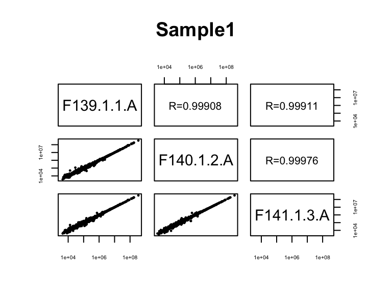

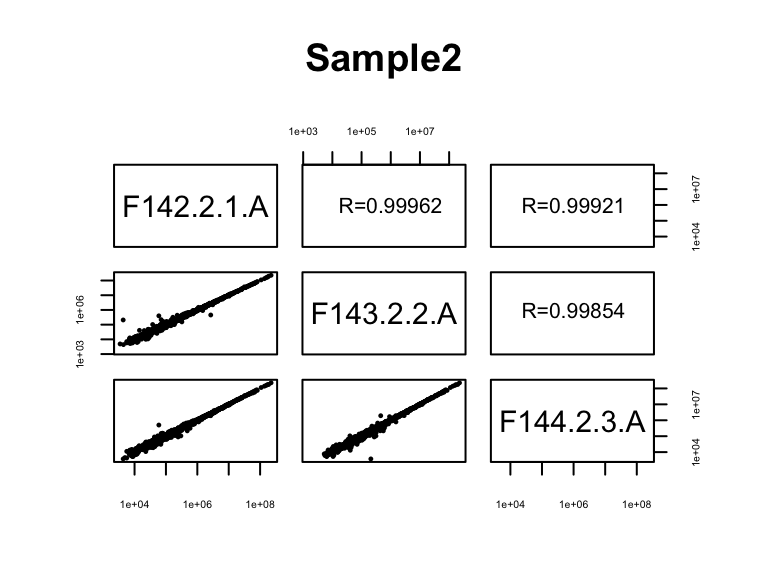

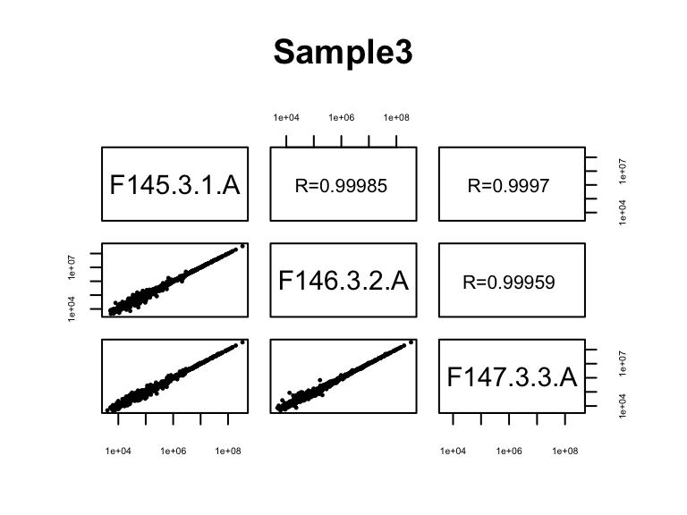

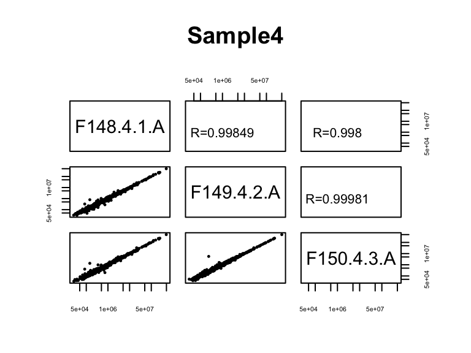

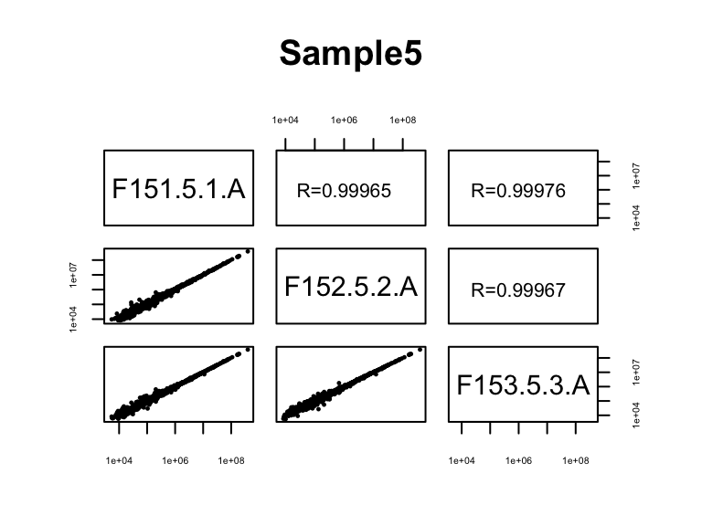

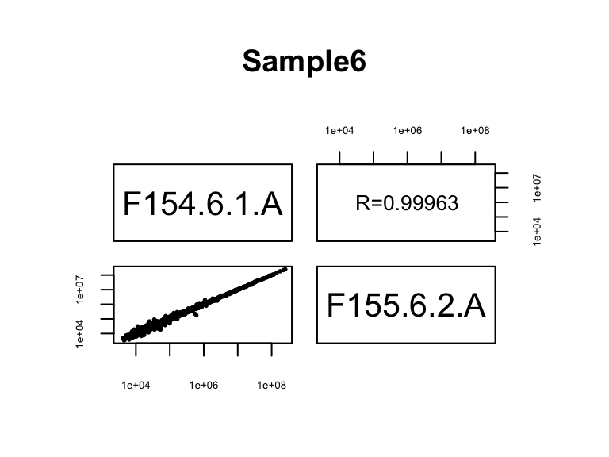

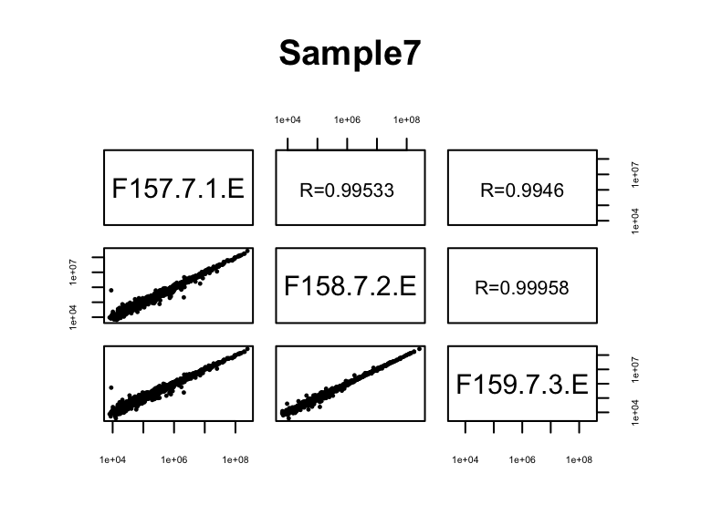

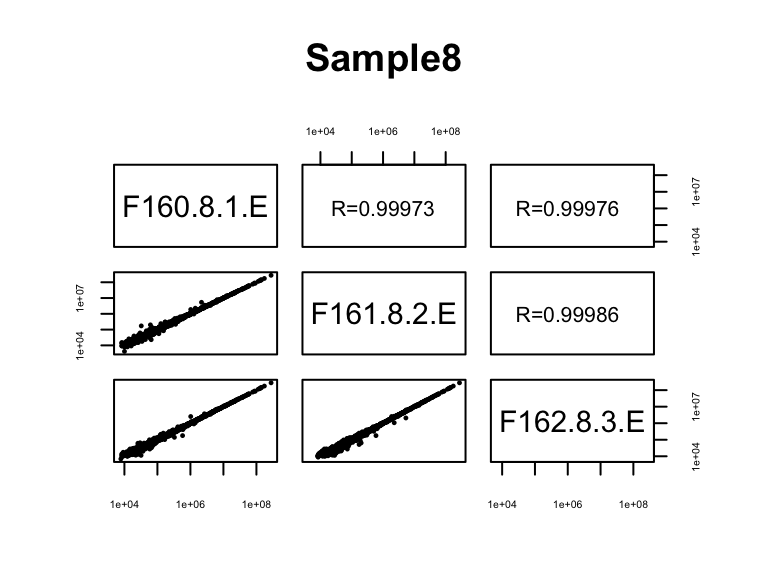

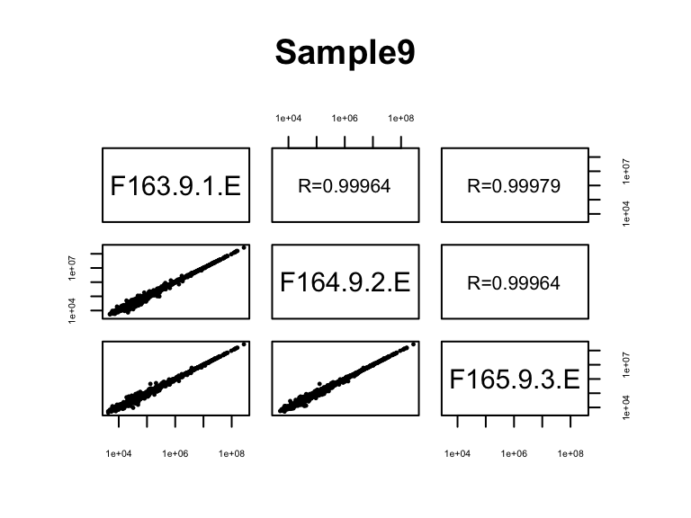

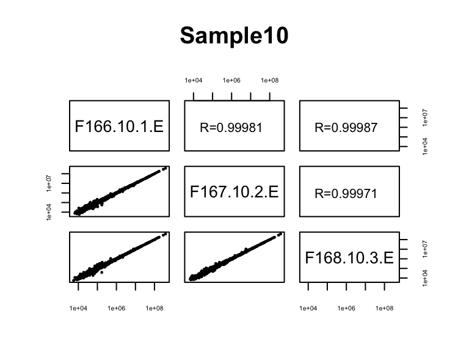

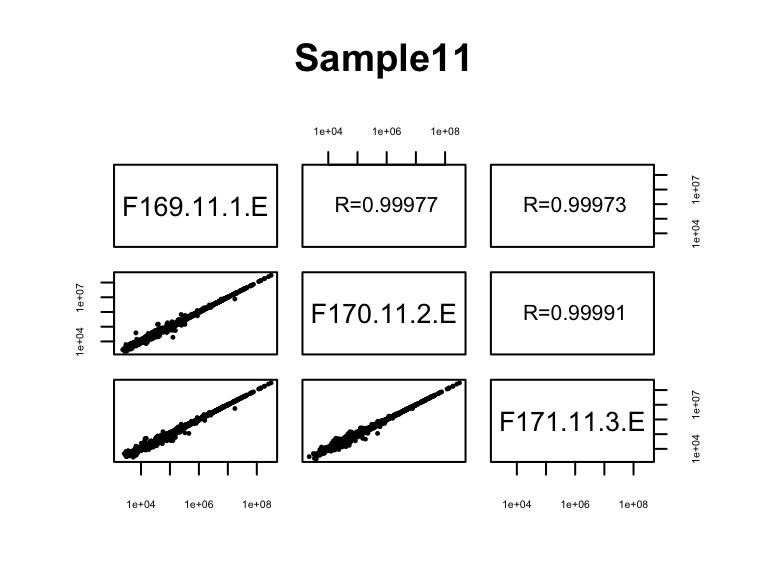

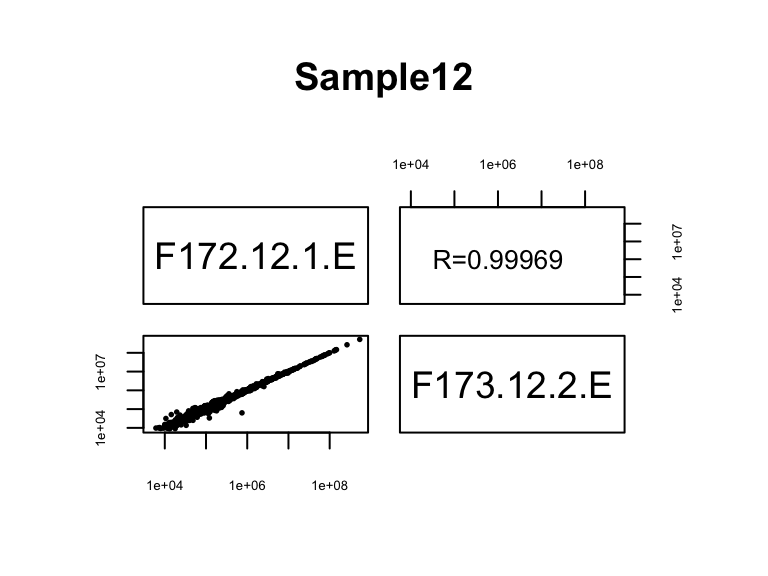

```r
techrep_cor_mats <- lapply(abundances_normalized_NA, cor, use="complete.obs")

panel.cor <- function(x, y, ...) {
    txt <- as.character(format(cor(x, y, use = "complete.obs"), digits=5))
    text(1e6, 1e6, labels=paste0("R=",txt), cex = 1)
}

#par(mfrow=c(4,3))
for (i in 1:12) {
    pairs(abundances_normalized_NA[[i]], main = sampleID[i],
          upper.panel=panel.cor,  log = "xy", pch = 19, cex = 0.3, cex.axis = 0.5)
}
```

Let’s make a consolidated figure for the publication.

**OOPS** can’t use layout or par() with `pairs()`. The following block does not evaluate currently.

```r
png(filename = "../Results/TechRep_Corrs.png", width = 10, height = 8,
    units = "in", pointsize = 10, res = 300)

# Set up a 3-row, 4-column layout, filling by columns
layout(matrix(1:12, nrow = 3, ncol = 4, byrow = FALSE))

# Adjust margins to fit multiple plots
par(mar = c(3, 3, 2, 1))

for (i in 1:12) {
    pairs(abundances_normalized_NA[[i]], main = sampleID[i],
          upper.panel=panel.cor,  log = "xy", pch = 19, cex = 0.3)
}
dev.off()
```

So indeed, the techreps have very high replication. Accordingly, we will average them to get a single biological replicate value.

## Biorep abundance dataframe

Importantly, this gives us our dataframe (`biorep_abund_mean`) of abundance values that will be provided to the `SummarizedExperiment` assay dataframe for `DEP` analysis.

```r
# Get mean across techreps for each biorep, store in matrix
biorep_abund_mean <- sapply(abundances_normalized_NA, FUN = function(x) {rowMeans(x, na.rm=T)} )
head(biorep_abund_mean)
```

```
##                    Sample1 Sample2 Sample3 Sample4 Sample5 Sample6  Sample7
## PIERAPT00000020304     NaN     NaN     NaN     NaN     NaN     NaN      NaN
## PIERAPT00000010371     NaN     NaN     NaN     NaN     NaN     NaN 12010.74
## PIERAPT00000024038     NaN     NaN     NaN     NaN     NaN     NaN      NaN
## PIERAPT00000021304     NaN     NaN     NaN     NaN     NaN     NaN      NaN
## PIERAPT00000013808     NaN     NaN     NaN     NaN     NaN     NaN      NaN
## PIERAPT00000023373     NaN     NaN     NaN     NaN     NaN     NaN      NaN
##                    Sample8  Sample9 Sample10 Sample11 Sample12
## PIERAPT00000020304     NaN      NaN      NaN      NaN      NaN
## PIERAPT00000010371 15644.4 118223.8 24968.41 53418.62 11368.75
## PIERAPT00000024038     NaN      NaN 67577.41 63983.51      NaN
## PIERAPT00000021304     NaN      NaN      NaN      NaN      NaN
## PIERAPT00000013808     NaN      NaN      NaN      NaN      NaN
## PIERAPT00000023373     NaN      NaN      NaN      NaN      NaN
```

```r
tail(biorep_abund_mean)
```

```
##                        Sample1    Sample2     Sample3     Sample4   Sample5
## PIERAPT00000008509    3971.827   143275.4    4915.893         NaN       NaN
## PIERAPT00000009795  543156.587   783243.9  840292.226  26911821.3 1317016.5
## PIERAPT00000016210 2416315.242  9307519.3 4753938.358 209247665.1 3380501.0
## PIERAPT00000014450 1423560.206 46676583.2  401704.569   1587889.8  497705.5
## PIERAPT00000035471 2028948.210 78757831.6  562503.810    918446.5 1384377.1
## PIERAPT00000028408 2904315.511  4042252.4 3908969.619 221463159.7 2187308.1
##                      Sample6    Sample7      Sample8     Sample9     Sample10
## PIERAPT00000008509       NaN   130489.3 8.107952e+03    4253.383     5447.405
## PIERAPT00000009795  715358.1  1006288.3 1.050827e+06  902408.530   734284.197
## PIERAPT00000016210 9028045.1 20123115.9 5.361069e+06 3364673.403 13663233.100
## PIERAPT00000014450  766664.7 12824145.5 1.420078e+08  949348.611  1187860.905
## PIERAPT00000035471 1050417.3 33469662.3 1.750704e+08 2226144.272  1866568.271
## PIERAPT00000028408 2868030.2 17328099.3 3.619335e+06 4223087.856  5934595.382
##                     Sample11  Sample12
## PIERAPT00000008509       NaN       NaN
## PIERAPT00000009795  136413.9  901496.8
## PIERAPT00000016210 1208569.0 9181427.9
## PIERAPT00000014450  816138.5 1399781.6
## PIERAPT00000035471 2520791.3 2029866.8
## PIERAPT00000028408  655494.0 2321625.4
```

## Biorep correlations

So now we can ask how consistent the abundance values are among biological replicates.

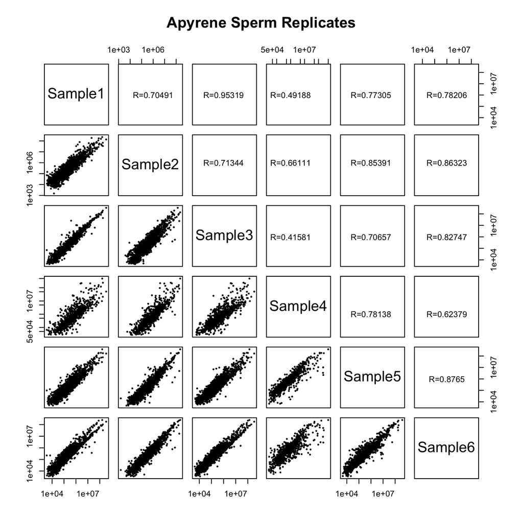

```r
pairs(biorep_abund_mean[,1:6], main = "Apyrene Sperm Replicates",
      upper.panel=panel.cor,  log = "xy", pch = 19, cex = 0.3)
```

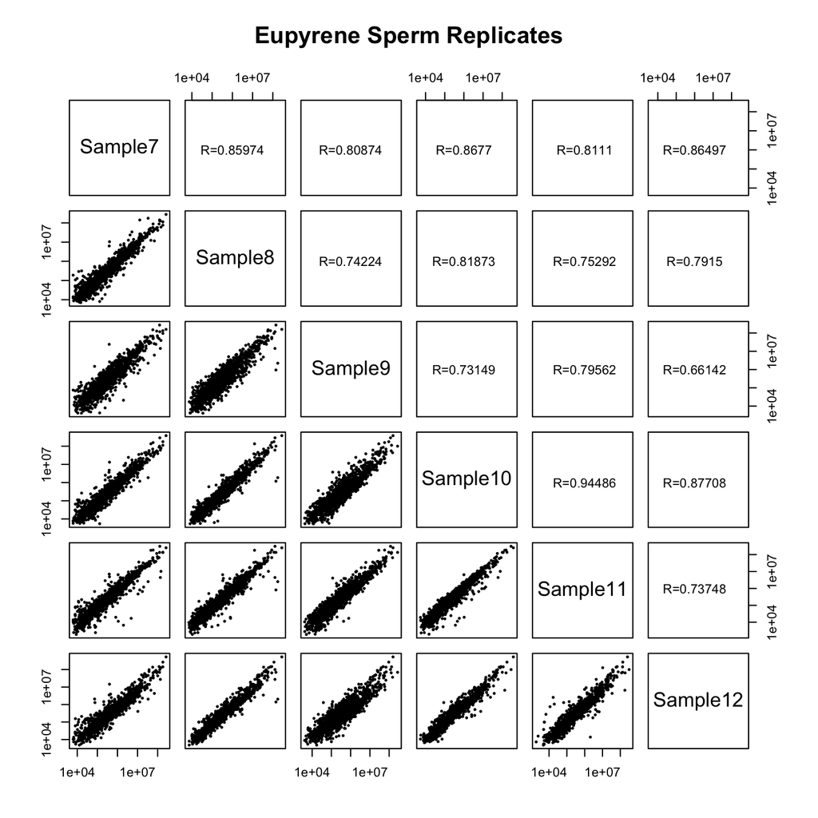

```r
pairs(biorep_abund_mean[,7:12], main = "Eupyrene Sperm Replicates",
      upper.panel=panel.cor,  log = "xy", pch = 19, cex = 0.3)
```

Generally the replication is OK, ranging roughly from 0.7-0.9, but seems to be a bit higher for eupyrene than apyrene.

## Make `SummarizedExperiment`

Now we can move on to assembling the other components of the SE for DEP. Let’s start with the colData (samples) dataframe

```r
spermType <- c(rep("Apyrene",6), rep("Eupyrene",6))
replicate <- c(1:6,1:6)
colData.df <- data.frame("label"=sampleID, "condition"= spermType, "replicate"=replicate)

# gsub(x=names(techreps_logical_df), pattern = "Sample\\d+\\.(F\\d+)\\.\\d\\.\\w", replacement = "\\1")
```

And now we make the *Features* dataframe

```r
# extract geneID
geneID <- gsub(x=proteins$Description, pattern = "geneID=(\\S+)\\sgenename=.+", replacement = "\\1")

feature.df <- data.frame("TrxID" = proteins$Accession, "GeneID" = geneID, "Npeptides" = proteins[[12]], "Ndetect.apy" = biorep_count_apy, "Ndetect.eup" = biorep_count_eup)

# DEP requires abundance data and metadata in the same dataframe...
dep.df <- data.frame(cbind(feature.df, biorep_abund_mean))

# This seems a completely superfluous step to use make_unique() to create
# "names" and "ID" columns which correspond to transcript and gene IDs.
# I'm just following the DEP workflow here, but probably could just manually
# create those two columns directly...
dep.df.uniq <- make_unique(proteins=dep.df, names = "TrxID", ids="GeneID")
```

Now we have the primary data (`biorep_abund_mean`), the gene/feature data, and the sample data. So we can assemble them into the `DEP` *SummarizedExperiment* object.

```r
pieris.se <- make_se(proteins_unique = dep.df.uniq, columns = grep(pattern="Sample", names(dep.df.uniq)), expdesign = colData.df)
```

Let’s write out the DEP summarized experiment object `pieris.se` for access in other contexts.

```r
save(pieris.se, file = "pieris_DEP_SE_object.Rdata")
```

# Test `DEP` functions

Now we can make use of the `DEP` functions!

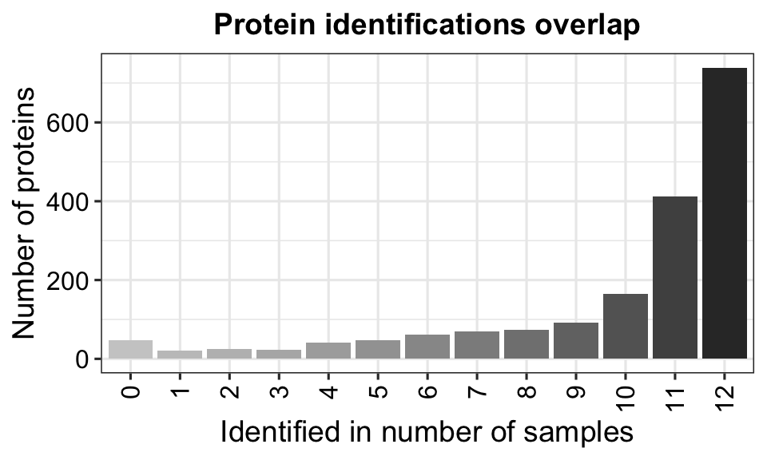

```r
plot_frequency(pieris.se)
```

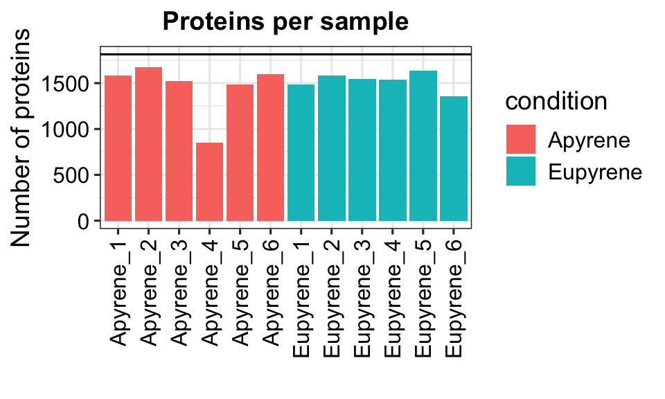

```r
plot_numbers(pieris.se)
```

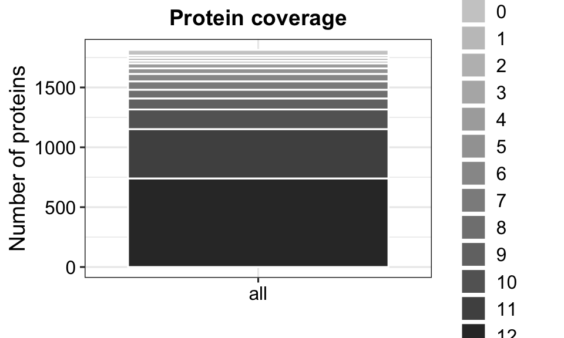

```r
plot_coverage(pieris.se)
```

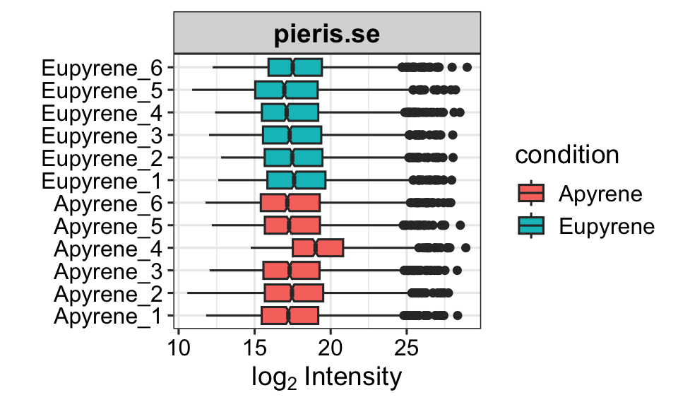

```r
plot_normalization(pieris.se)
```

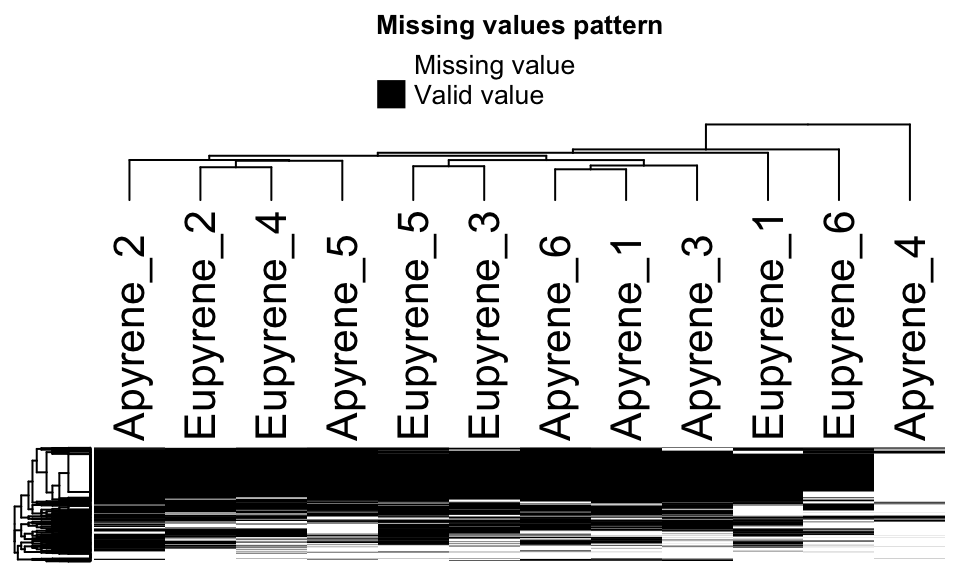

```r
plot_missval(pieris.se)
```

## Pub figure: counts & abundance

Make figure for publication, combine `plot_numbers()` and `plot_normalization()`

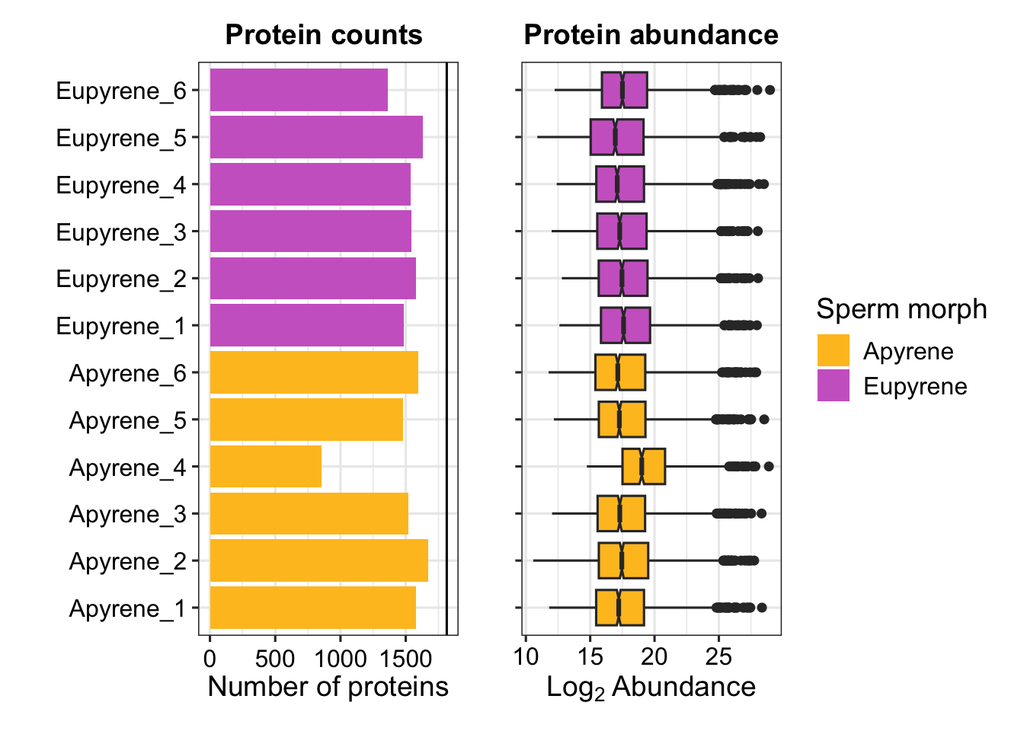

```r
library(patchwork)
library(ggplot2)


#myCols <- c("orange2", "skyblue2")
myCols <- c("goldenrod1", "orchid3")

pnumb <- plot_numbers(pieris.se) +
  scale_fill_manual(values = myCols) + coord_flip() +
  theme(axis.text.x = element_text(angle = 0, hjust = 0.5)) +
  ggtitle(label = "Protein counts ") +
  guides(fill=guide_legend(title="Sperm morph"))
#pnumb

pnorm <- plot_normalization(pieris.se) +
  scale_fill_manual(values = myCols) +
  theme(
  strip.background = element_blank(),
  strip.text.x = element_blank(),
  axis.text.y=element_blank(),
  legend.position = "none") +
  ggtitle(label = "Protein abundance") +
  labs(x = "", y = expression(Log[2] ~ "Abundance"))

#pnorm


outplot <- pnumb + pnorm + plot_layout(guides = "collect")

print(outplot)
```

```r
ggsave(plot = outplot, filename = "../Results/Count-Abund_prefilter.pdf",
       width = 180, height = 90, scale=1.8, units = "mm")

outplotlab <- pnumb + pnorm + plot_layout(guides = "collect") +
  plot_annotation(tag_levels = 'A')

ggsave(plot = outplotlab, filename = "../Results/Count-Abund_prefilter_ABlabels.jpg",
       width = 180, height = 90, scale=1.8, units = "mm")

ggsave(plot = outplotlab, filename = "../Results/Count-Abund_prefilter_ABlabels.pdf",
       width = 180, height = 90, scale=1.8, units = "mm")
```